# Lab Report Structure and Guidelines (ENS-215)

#### **Important notes**

- Lab assignments (like all other assignments) must be your own work. You are encouraged to discuss with your classmates, however you may not copy anyone else’s code. Make sure to ask me if you have any questions or doubts about what is acceptable.
- Your code must run exactly as is on anyone’s computer. I need to be able to open your file and run it exactly as is.
- A very helpful guide on formatting R Markdown documents for assignments is available at http://www.stat.cmu.edu/~cshalizi/rmarkdown/. You can also find a helpful R Markdown “cheat-sheet” at https://www.rstudio.com/resources/cheatsheets/

#### **Lab report formatting requirements**

- Your lab must have a title and a header (see above)
- Your will submit your assignment as both a R Notebook file (.Rmd) and html file via our Nexus site
- Your file MUST be named according to the following format `Lab_#_Lastname`
- So for example if I were to submit an assignment for the 2nd lab of the term my file name (including the extension) would be `Lab_2_Stahl.Rmd`

## Main body of the lab

Here you will weave together your code, comments/text, and outputs (figures,tables,…) into a coherent and logically organized document.

- **Your lab report content needs to have:**
  - Code that is well documented with comments.
  - Content that is clearly divided into sections with section titles.
  - Readable code (e.g. logically named variables, line breaks and spacing to make code easier to read, use of headers to break up sections,…).
  - No unnecessary or extraneous code (e.g. you should not keep “scratch work” or any code that is ultimately not used).
  - Clearly labeled output (e.g. use comments and/or headers that clearly identify the output).
  - Figures must be properly formatted. This includes (but is not limited to) the use of axis labels, legends (where applicable), reasonable axis scales, reasonably sized data points/lines.
  - Answers/responses to all of the questions/parts of the lab.
  - If you rely on outside sources when writing your discussion/responses they need to be cited

**Example “main body” content presented below**

### Part 1: Visualizing daily average air temperature data from Albany, NY

#### Load in the required libraries

```r
library(tidyverse)
library(lubridate)
```

#### Load in the daily average air temperature data

```r
## Load in data
airtemps <- read_csv('https://github.com/stahlm/stahlm.github.io/raw/master/ENS_215/Data/Albany_Temperature_Data.csv') # read in data from class github site
airtemps$MDY <- mdy(airtemps$DATE) # convert dates into appropriate date format
```

#### Below are the summary statistics for Albany air temperature

```r
summary(airtemps$TAVG)
```

```
##    Min. 1st Qu.  Median    Mean 3rd Qu.    Max.
##    3.00   36.00   53.00   50.49   67.00   80.00
```

You might add some discussion here if required or merited.

#### Plot the temperature data for Albany, NY

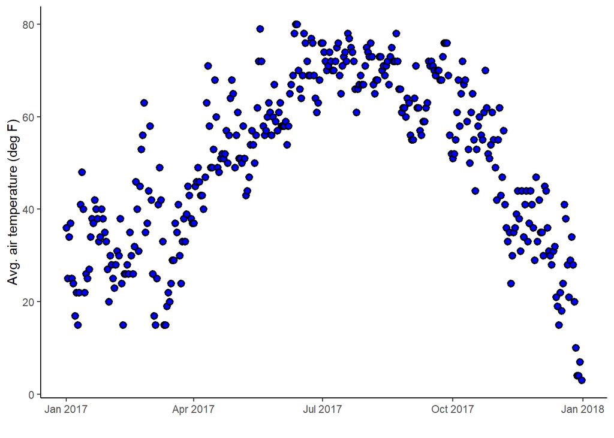

```r
ggplot(airtemps,aes(MDY,TAVG)) + geom_point(shape = 21, color ="black", fill = "blue", size = 2, stroke = 1) + xlab("") + ylab("Avg. air temperature (deg F)") + theme_classic()
```

If a response/discussion regarding the above analysis is required or appropriate then you would put it here. When responding to questions your writing your discussion you should treat it as you would any other lab write-up (i.e. the writing and content should be clear, accurate, and sufficiently detailed).